# CRS_Project_MUDITDESAI

```python
import pandas as pd
import numpy as np
```

```python
df= pd.read_csv('311_Service_Requests_from_2010_to_Present.csv')
```

```python
df.info()
```

```
<class 'pandas.core.frame.DataFrame'>
RangeIndex: 300698 entries, 0 to 300697
Data columns (total 53 columns):
Unique Key                        300698 non-null int64
Created Date                      300698 non-null object
Closed Date                       298534 non-null object
Agency                            300698 non-null object
Agency Name                       300698 non-null object
Complaint Type                    300698 non-null object
Descriptor                        294784 non-null object
Location Type                     300567 non-null object
Incident Zip                      298083 non-null float64
Incident Address                  256288 non-null object
Street Name                       256288 non-null object
Cross Street 1                    251419 non-null object
Cross Street 2                    250919 non-null object
Intersection Street 1             43858 non-null object
Intersection Street 2             43362 non-null object
Address Type                      297883 non-null object
City                              298084 non-null object
Landmark                          349 non-null object
Facility Type                     298527 non-null object
Status                            300698 non-null object
Due Date                          300695 non-null object
Resolution Description            300698 non-null object
Resolution Action Updated Date    298511 non-null object
Community Board                   300698 non-null object
Borough                           300698 non-null object
X Coordinate (State Plane)        297158 non-null float64
Y Coordinate (State Plane)        297158 non-null float64
Park Facility Name                300698 non-null object
Park Borough                      300698 non-null object
School Name                       300698 non-null object
School Number                     300698 non-null object
School Region                     300697 non-null object
School Code                       300697 non-null object
School Phone Number               300698 non-null object
School Address                    300698 non-null object
School City                       300698 non-null object
School State                      300698 non-null object
School Zip                        300697 non-null object
School Not Found                  300698 non-null object
School or Citywide Complaint      0 non-null float64
Vehicle Type                      0 non-null float64
Taxi Company Borough              0 non-null float64
Taxi Pick Up Location             0 non-null float64
Bridge Highway Name               243 non-null object
Bridge Highway Direction          243 non-null object
Road Ramp                         213 non-null object
Bridge Highway Segment            213 non-null object
Garage Lot Name                   0 non-null float64
Ferry Direction                   1 non-null object
Ferry Terminal Name               2 non-null object
Latitude                          297158 non-null float64
Longitude                         297158 non-null float64
Location                          297158 non-null object
dtypes: float64(10), int64(1), object(42)
memory usage: 121.6+ MB
```

Create date and close date are read as object, need to be converted to datetime. It is also observed that, Create date has no null value but clsoe date has some null value.

```python
df.describe()
```

|  | Unique Key | Incident Zip | X Coordinate (State Plane) | Y Coordinate (State Plane) | School or Citywide Complaint | Vehicle Type | Taxi Company Borough | Taxi Pick Up Location | Garage Lot Name | Latitude | Longitude |
| --- | --- | --- | --- | --- | --- | --- | --- | --- | --- | --- | --- |
| count | 3.006980e+05 | 298083.000000 | 2.971580e+05 | 297158.000000 | 0.0 | 0.0 | 0.0 | 0.0 | 0.0 | 297158.000000 | 297158.000000 |
| mean | 3.130054e+07 | 10848.888645 | 1.004854e+06 | 203754.534416 | NaN | NaN | NaN | NaN | NaN | 40.725885 | -73.925630 |
| std | 5.738547e+05 | 583.182081 | 2.175338e+04 | 29880.183529 | NaN | NaN | NaN | NaN | NaN | 0.082012 | 0.078454 |
| min | 3.027948e+07 | 83.000000 | 9.133570e+05 | 121219.000000 | NaN | NaN | NaN | NaN | NaN | 40.499135 | -74.254937 |
| 25% | 3.080118e+07 | 10310.000000 | 9.919752e+05 | 183343.000000 | NaN | NaN | NaN | NaN | NaN | 40.669796 | -73.972142 |
| 50% | 3.130436e+07 | 11208.000000 | 1.003158e+06 | 201110.500000 | NaN | NaN | NaN | NaN | NaN | 40.718661 | -73.931781 |
| 75% | 3.178446e+07 | 11238.000000 | 1.018372e+06 | 224125.250000 | NaN | NaN | NaN | NaN | NaN | 40.781840 | -73.876805 |
| max | 3.231065e+07 | 11697.000000 | 1.067173e+06 | 271876.000000 | NaN | NaN | NaN | NaN | NaN | 40.912869 | -73.700760 |

```python
df['Created Date'] = pd.to_datetime(df['Created Date'])
```

```python
df['Closed Date'] = pd.to_datetime(df['Closed Date'])
```

We have converted 'Created Date'and 'Closed Date'to date time

```python
df['Request_Closing_Time'] = (df['Closed Date'] - df['Created Date']).dt.days
```

df['c'] = (df['B'] - df['a']).dt.days where c is the difference between closing date and created date

a new column 'Request_Closing_Time' as the time elapsed between request creation and request closing is created

```python
print(df.head())
```

```
   Unique Key        Created Date         Closed Date Agency  \
0    32310363 2015-12-31 23:59:00 2016-01-01 00:55:00   NYPD
1    32309934 2015-12-31 23:59:00 2016-01-01 01:26:00   NYPD
2    32309159 2015-12-31 23:59:00 2016-01-01 04:51:00   NYPD
3    32305098 2015-12-31 23:57:00 2016-01-01 07:43:00   NYPD
4    32306529 2015-12-31 23:56:00 2016-01-01 03:24:00   NYPD

                       Agency Name           Complaint Type  \
0  New York City Police Department  Noise - Street/Sidewalk
1  New York City Police Department         Blocked Driveway
2  New York City Police Department         Blocked Driveway
3  New York City Police Department          Illegal Parking
4  New York City Police Department          Illegal Parking

                     Descriptor    Location Type  Incident Zip  \
```

[output cut: 35 more lines]

```python
df = df[pd.notnull(df['Closed Date'])]
```

```python
df.info()
```

```
<class 'pandas.core.frame.DataFrame'>
Int64Index: 298534 entries, 0 to 300697
Data columns (total 54 columns):
Unique Key                        298534 non-null int64
Created Date                      298534 non-null datetime64[ns]
Closed Date                       298534 non-null datetime64[ns]
Agency                            298534 non-null object
Agency Name                       298534 non-null object
Complaint Type                    298534 non-null object
Descriptor                        292625 non-null object
Location Type                     298406 non-null object
Incident Zip                      298027 non-null float64
Incident Address                  254137 non-null object
Street Name                       254137 non-null object
Cross Street 1                    250971 non-null object
Cross Street 2                    250881 non-null object
Intersection Street 1             43440 non-null object
Intersection Street 2             43354 non-null object
Address Type                      297827 non-null object
City                              298028 non-null object
Landmark                          349 non-null object
Facility Type                     298519 non-null object
Status                            298534 non-null object
Due Date                          298533 non-null object
Resolution Description            298534 non-null object
Resolution Action Updated Date    298495 non-null object
Community Board                   298534 non-null object
Borough                           298534 non-null object
X Coordinate (State Plane)        297102 non-null float64
Y Coordinate (State Plane)        297102 non-null float64
Park Facility Name                298534 non-null object
Park Borough                      298534 non-null object
School Name                       298534 non-null object
School Number                     298534 non-null object
School Region                     298533 non-null object
School Code                       298533 non-null object
School Phone Number               298534 non-null object
School Address                    298534 non-null object
School City                       298534 non-null object
School State                      298534 non-null object
School Zip                        298533 non-null object
School Not Found                  298534 non-null object
School or Citywide Complaint      0 non-null float64
Vehicle Type                      0 non-null float64
Taxi Company Borough              0 non-null float64
Taxi Pick Up Location             0 non-null float64
Bridge Highway Name               243 non-null object
Bridge Highway Direction          243 non-null object
Road Ramp                         213 non-null object
Bridge Highway Segment            213 non-null object
Garage Lot Name                   0 non-null float64
Ferry Direction                   0 non-null object
Ferry Terminal Name               0 non-null object
Latitude                          297102 non-null float64
Longitude                         297102 non-null float64
Location                          297102 non-null object
Request_Closing_Time              298534 non-null float64
dtypes: datetime64[ns](2), float64(11), int64(1), object(40)
memory usage: 125.3+ MB
```

```python
df.describe()
```

|  | Unique Key | Incident Zip | X Coordinate (State Plane) | Y Coordinate (State Plane) | School or Citywide Complaint | Vehicle Type | Taxi Company Borough | Taxi Pick Up Location | Garage Lot Name | Latitude | Longitude | Request_Closing_Time |
| --- | --- | --- | --- | --- | --- | --- | --- | --- | --- | --- | --- | --- |
| count | 2.985340e+05 | 298027.000000 | 2.971020e+05 | 297102.000000 | 0.0 | 0.0 | 0.0 | 0.0 | 0.0 | 297102.000000 | 297102.000000 | 298534.000000 |
| mean | 3.130087e+07 | 10848.929886 | 1.004855e+06 | 203753.772782 | NaN | NaN | NaN | NaN | NaN | 40.725883 | -73.925625 | 0.016052 |
| std | 5.740837e+05 | 583.173185 | 2.175284e+04 | 29880.600637 | NaN | NaN | NaN | NaN | NaN | 0.082014 | 0.078452 | 0.181765 |
| min | 3.027948e+07 | 83.000000 | 9.133570e+05 | 121219.000000 | NaN | NaN | NaN | NaN | NaN | 40.499135 | -74.254937 | 0.000000 |
| 25% | 3.080121e+07 | 10310.000000 | 9.919760e+05 | 183337.500000 | NaN | NaN | NaN | NaN | NaN | 40.669789 | -73.972142 | 0.000000 |
| 50% | 3.130562e+07 | 11208.000000 | 1.003160e+06 | 201110.000000 | NaN | NaN | NaN | NaN | NaN | 40.718655 | -73.931780 | 0.000000 |
| 75% | 3.178561e+07 | 11238.000000 | 1.018372e+06 | 224123.000000 | NaN | NaN | NaN | NaN | NaN | 40.781816 | -73.876805 | 0.000000 |
| max | 3.231065e+07 | 11697.000000 | 1.067173e+06 | 271876.000000 | NaN | NaN | NaN | NaN | NaN | 40.912869 | -73.700760 | 24.000000 |

```python
pd.crosstab(df["Agency Name"],df["Complaint Type"],margins=True)
```

| Complaint Type Agency Name | Agency Issues | Animal Abuse | Animal in a Park | Bike/Roller/Skate Chronic | Blocked Driveway | Derelict Vehicle | Disorderly Youth | Drinking | Graffiti | Homeless Encampment | ... | Noise - Park | Noise - Street/Sidewalk | Noise - Vehicle | Panhandling | Posting Advertisement | Squeegee | Traffic | Urinating in Public | Vending | All |
| --- | --- | --- | --- | --- | --- | --- | --- | --- | --- | --- | --- | --- | --- | --- | --- | --- | --- | --- | --- | --- | --- |
| Internal Affairs Bureau | 6 | 0 | 0 | 0 | 0 | 0 | 0 | 0 | 0 | 0 | ... | 0 | 0 | 0 | 0 | 0 | 0 | 0 | 0 | 0 | 6 |
| NYPD | 0 | 0 | 0 | 0 | 1 | 0 | 0 | 0 | 0 | 0 | ... | 0 | 0 | 0 | 0 | 0 | 0 | 0 | 0 | 0 | 1 |
| New York City Police Department | 0 | 7768 | 1 | 424 | 76809 | 17588 | 286 | 1275 | 113 | 4416 | ... | 4022 | 48076 | 17033 | 305 | 648 | 4 | 4496 | 592 | 3795 | 298527 |
| All | 6 | 7768 | 1 | 424 | 76810 | 17588 | 286 | 1275 | 113 | 4416 | ... | 4022 | 48076 | 17033 | 305 | 648 | 4 | 4496 | 592 | 3795 | 298534 |

4 rows × 24 columns

1) It is found that, Most of the complaints are registered by "New York City Police Department"

```python
pd.crosstab(df["Location Type"],df["Complaint Type"],margins=False)
```

| Complaint Type Location Type | Animal Abuse | Animal in a Park | Bike/Roller/Skate Chronic | Blocked Driveway | Derelict Vehicle | Disorderly Youth | Drinking | Graffiti | Homeless Encampment | Illegal Fireworks | ... | Noise - House of Worship | Noise - Park | Noise - Street/Sidewalk | Noise - Vehicle | Panhandling | Posting Advertisement | Squeegee | Traffic | Urinating in Public | Vending |
| --- | --- | --- | --- | --- | --- | --- | --- | --- | --- | --- | --- | --- | --- | --- | --- | --- | --- | --- | --- | --- | --- |
| Bridge | 0 | 0 | 0 | 0 | 0 | 0 | 0 | 0 | 2 | 0 | ... | 0 | 0 | 0 | 0 | 0 | 0 | 0 | 0 | 0 | 0 |
| Club/Bar/Restaurant | 0 | 0 | 0 | 0 | 0 | 0 | 365 | 0 | 0 | 0 | ... | 0 | 0 | 0 | 0 | 0 | 0 | 0 | 0 | 21 | 0 |
| Commercial | 62 | 0 | 0 | 0 | 0 | 0 | 0 | 0 | 0 | 0 | ... | 0 | 0 | 0 | 0 | 0 | 0 | 0 | 0 | 0 | 0 |
| Highway | 0 | 0 | 0 | 0 | 13 | 0 | 0 | 0 | 15 | 0 | ... | 0 | 0 | 0 | 0 | 0 | 0 | 0 | 186 | 0 | 0 |
| House and Store | 93 | 0 | 0 | 0 | 0 | 0 | 0 | 0 | 0 | 0 | ... | 0 | 0 | 0 | 0 | 0 | 0 | 0 | 0 | 0 | 0 |
| House of Worship | 0 | 0 | 0 | 0 | 0 | 0 | 0 | 0 | 0 | 0 | ... | 927 | 0 | 0 | 0 | 0 | 0 | 0 | 0 | 0 | 0 |
| Park | 0 | 1 | 0 | 0 | 0 | 0 | 0 | 0 | 0 | 0 | ... | 0 | 0 | 0 | 0 | 0 | 0 | 0 | 0 | 0 | 0 |
| Park/Playground | 122 | 0 | 0 | 0 | 0 | 0 | 98 | 0 | 353 | 8 | ... | 0 | 4021 | 0 | 0 | 6 | 0 | 0 | 0 | 38 | 105 |
| Parking Lot | 110 | 0 | 0 | 0 | 0 | 0 | 0 | 0 | 0 | 0 | ... | 0 | 0 | 0 | 0 | 0 | 7 | 0 | 0 | 0 | 0 |
| Residential Building | 227 | 0 | 0 | 0 | 0 | 0 | 0 | 0 | 0 | 0 | ... | 0 | 0 | 0 | 0 | 0 | 0 | 0 | 0 | 0 | 0 |
| Residential Building/House | 5081 | 0 | 25 | 0 | 0 | 77 | 289 | 56 | 983 | 33 | ... | 0 | 0 | 0 | 0 | 16 | 54 | 0 | 0 | 138 | 201 |
| Roadway Tunnel | 0 | 0 | 0 | 0 | 5 | 0 | 0 | 0 | 1 | 0 | ... | 0 | 0 | 0 | 0 | 0 | 0 | 0 | 29 | 0 | 0 |
| Store/Commercial | 521 | 0 | 53 | 0 | 0 | 8 | 90 | 32 | 512 | 2 | ... | 0 | 0 | 0 | 0 | 60 | 6 | 0 | 0 | 66 | 432 |
| Street/Sidewalk | 1527 | 0 | 346 | 76773 | 17485 | 201 | 432 | 25 | 2541 | 125 | ... | 0 | 0 | 48067 | 17030 | 223 | 580 | 4 | 4276 | 316 | 3055 |
| Subway Station | 22 | 0 | 0 | 0 | 0 | 0 | 0 | 0 | 0 | 0 | ... | 0 | 0 | 0 | 0 | 0 | 0 | 0 | 0 | 12 | 0 |
| Vacant Lot | 0 | 0 | 0 | 0 | 77 | 0 | 0 | 0 | 0 | 0 | ... | 0 | 0 | 0 | 0 | 0 | 0 | 0 | 0 | 0 | 0 |

16 rows × 22 columns

2) Maximum complaints are on street/Sidewalk due to blocked Driveway (76773) 3) Also Maximum complaints are done on Street/Sidewalk

```python
import matplotlib.pylab as plt
import seaborn as sns
```

```
array([[<matplotlib.axes._subplots.AxesSubplot object at 0x000001DA83F6E630>,
      dtype=object)
```

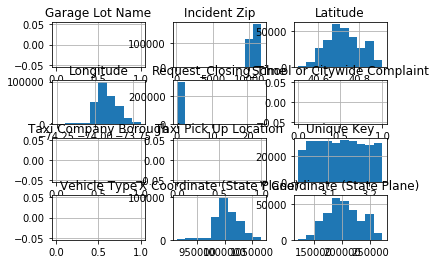

```python
df.hist()
```

```python
plt.figure(figsize=(150,70))
sns.set(font_scale=4)
ax = sns.countplot(x="Complaint Type", data=df)
plt.title('Distribution of Complaint Type')
plt.xlabel('Complaint Type')
plt.ylabel('No. Of Complaints')
```

[figure not shown]

```python
df.corr()
```

|  | Unique Key | Incident Zip | X Coordinate (State Plane) | Y Coordinate (State Plane) | School or Citywide Complaint | Vehicle Type | Taxi Company Borough | Taxi Pick Up Location | Garage Lot Name | Latitude | Longitude | Request_Closing_Time |
| --- | --- | --- | --- | --- | --- | --- | --- | --- | --- | --- | --- | --- |
| Unique Key | 1.000000 | 0.024897 | -0.009154 | -0.032271 | NaN | NaN | NaN | NaN | NaN | -0.032276 | -0.009158 | 0.033525 |
| Incident Zip | 0.024897 | 1.000000 | 0.392015 | -0.498239 | NaN | NaN | NaN | NaN | NaN | -0.498492 | 0.391360 | 0.019290 |
| X Coordinate (State Plane) | -0.009154 | 0.392015 | 1.000000 | 0.364513 | NaN | NaN | NaN | NaN | NaN | 0.363998 | 0.999999 | 0.060981 |
| Y Coordinate (State Plane) | -0.032271 | -0.498239 | 0.364513 | 1.000000 | NaN | NaN | NaN | NaN | NaN | 1.000000 | 0.365477 | 0.013327 |
| School or Citywide Complaint | NaN | NaN | NaN | NaN | NaN | NaN | NaN | NaN | NaN | NaN | NaN | NaN |
| Vehicle Type | NaN | NaN | NaN | NaN | NaN | NaN | NaN | NaN | NaN | NaN | NaN | NaN |
| Taxi Company Borough | NaN | NaN | NaN | NaN | NaN | NaN | NaN | NaN | NaN | NaN | NaN | NaN |
| Taxi Pick Up Location | NaN | NaN | NaN | NaN | NaN | NaN | NaN | NaN | NaN | NaN | NaN | NaN |
| Garage Lot Name | NaN | NaN | NaN | NaN | NaN | NaN | NaN | NaN | NaN | NaN | NaN | NaN |
| Latitude | -0.032276 | -0.498492 | 0.363998 | 1.000000 | NaN | NaN | NaN | NaN | NaN | 1.000000 | 0.364962 | 0.013271 |
| Longitude | -0.009158 | 0.391360 | 0.999999 | 0.365477 | NaN | NaN | NaN | NaN | NaN | 0.364962 | 1.000000 | 0.060996 |
| Request_Closing_Time | 0.033525 | 0.019290 | 0.060981 | 0.013327 | NaN | NaN | NaN | NaN | NaN | 0.013271 | 0.060996 | 1.000000 |

4) There is a strong postiive corelation between Longitude and X Coordinate

```python
pd.pivot_table(df,index=["Location Type","Complaint Type"],values=['Request_Closing_Time'])
```

| Location Type | Complaint Type | Request_Closing_Time |
| --- | --- | --- |
| Bridge | Homeless Encampment | 0.000000 |
| Club/Bar/Restaurant | Drinking | 0.021918 |
|  | Noise - Commercial | 0.007185 |
|  | Urinating in Public | 0.142857 |
| Commercial | Animal Abuse | 0.032258 |
| Highway | Derelict Vehicle | 0.153846 |
|  | Homeless Encampment | 0.000000 |
|  | Traffic | 0.005376 |
| House and Store | Animal Abuse | 0.021505 |
| House of Worship | Noise - House of Worship | 0.009709 |
| Park | Animal in a Park | 14.000000 |
| Park/Playground | Animal Abuse | 0.016393 |
|  | Drinking | 0.000000 |
|  | Homeless Encampment | 0.005666 |
|  | Illegal Fireworks | 0.000000 |
|  | Noise - Park | 0.006466 |
|  | Panhandling | 0.000000 |
|  | Urinating in Public | 0.000000 |
|  | Vending | 0.000000 |
| Parking Lot | Animal Abuse | 0.045455 |
|  | Posting Advertisement | 0.000000 |
| Residential Building | Animal Abuse | 0.017621 |
| Residential Building/House | Animal Abuse | 0.022830 |
|  | Bike/Roller/Skate Chronic | 0.000000 |
|  | Disorderly Youth | 0.000000 |
|  | Drinking | 0.003460 |
|  | Graffiti | 0.035714 |
|  | Homeless Encampment | 0.014242 |
|  | Illegal Fireworks | 0.000000 |
|  | Panhandling | 0.000000 |
| ... | ... | ... |
| Store/Commercial | Drinking | 0.000000 |
|  | Graffiti | 0.000000 |
|  | Homeless Encampment | 0.009766 |
|  | Illegal Fireworks | 0.000000 |
|  | Noise - Commercial | 0.005869 |
|  | Panhandling | 0.000000 |
|  | Posting Advertisement | 0.000000 |
|  | Urinating in Public | 0.015152 |
|  | Vending | 0.004630 |
| Street/Sidewalk | Animal Abuse | 0.036673 |
|  | Bike/Roller/Skate Chronic | 0.008671 |
|  | Blocked Driveway | 0.014862 |
|  | Derelict Vehicle | 0.073549 |
|  | Disorderly Youth | 0.004975 |
|  | Drinking | 0.009259 |
|  | Graffiti | 0.200000 |
|  | Homeless Encampment | 0.011019 |
|  | Illegal Fireworks | 0.008000 |
|  | Illegal Parking | 0.014927 |
|  | Noise - Street/Sidewalk | 0.009341 |
|  | Noise - Vehicle | 0.008867 |
|  | Panhandling | 0.035874 |
|  | Posting Advertisement | 0.001724 |
|  | Squeegee | 0.000000 |
|  | Traffic | 0.010758 |
|  | Urinating in Public | 0.003165 |
|  | Vending | 0.009820 |
| Subway Station | Animal Abuse | 0.000000 |
|  | Urinating in Public | 0.000000 |
| Vacant Lot | Derelict Vehicle | 0.142857 |

69 rows × 1 columns

```python
import scipy.stats as stats
import statsmodels
import statsmodels.api as sm
import statsmodels.formula.api as smf
from statsmodels.formula.api import ols
from sklearn.linear_model import LinearRegression
```

```python
df['Complaint Type1'] = pd.Categorical(df['Complaint Type'])
```

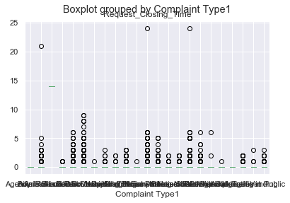

```python
df.boxplot('Request_Closing_Time', by='Complaint Type1')
```

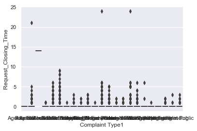

```python
sns.set(font_scale=1)
spread = np.random.rand(100) * 1000
ax = sns.boxplot(x = "Complaint Type1", y = "Request_Closing_Time", data = df, palette="Set1", linewidth = 2)
```

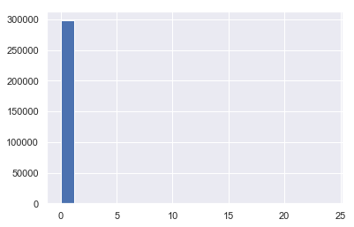

```python
plt.hist(df['Request_Closing_Time'], bins='auto')
```

```python
print(stats.normaltest(df['Request_Closing_Time'], axis=0))
```

```
NormaltestResult(statistic=821999.7644654972, pvalue=0.0)
```

```python
model = smf.ols('Request_Closing_Time~Complaint Type1', data=df).fit()
```

[output not shown]

```python
model = ols('Request_Closing_Time~Complaint Type1',data=df).fit()
```

[output not shown]

```python
df = pd.DataFrame({'Complaint Type1':X, 'Request_Closing_Time':Y})
model = smf.ols('Y~X', data=df).fit()
```

[output not shown]

```python
table = sm.stats.anova_lm(model, typ=2)
print(table)
```

[output not shown]